# Esame Parte 2 - Bayesian Data Analysis (Stefanini)

Giulio Vannini

Per prima cosa procediamo a installare le librerie…non è una procedura banale in questo caso!

```r
####### INSTALLARE PRIMA DI ESEGUIRE
#install.packages(c("bnlearn", "RBGL", "gRain", "igraph"))
#source("https://bioconductor.org/biocLite.R")
#biocLite("RBGL")
#biocLite("graph")
#biocLite("Rgraphviz")
#biocLite("BiocGenerics")

library(bnlearn)
library(gRain)
library(igraph)
library(Rgraphviz)
library(tidyverse)
library(pcalg)
library(dplyr)
```

# Esercizio 1

Richiamate le librerie necessarie carico la workspace insuranceDF.RData. Quante unità statistiche contiene? Le varibili sono tutte oggetti fattore? Quanti missing values ci sono in ciascuna variabile?

```r
load("C:/Users/GiulioVannini/Documents/Visual Studio 2017/Projects/MABIDA2017/Stefanini/Esame Parte 2/insuranceDF.RData")
nrow(insuranceDF)
```

```
## [1] 10000
```

```r
names(insuranceDF)
```

```
##  [1] "GoodStudent"  "Age"          "SocioEcon"    "RiskAversion"
##  [5] "VehicleYear"  "ThisCarDam"   "RuggedAuto"   "Accident"
##  [9] "MakeModel"    "DrivQuality"  "Mileage"      "Antilock"
## [13] "DrivingSkill" "SeniorTrain"  "ThisCarCost"  "Theft"
## [17] "CarValue"     "HomeBase"     "AntiTheft"    "PropCost"
## [21] "OtherCarCost" "OtherCar"     "MedCost"      "Cushioning"
## [25] "Airbag"       "ILiCost"      "DrivHist"
```

```r
str(insuranceDF)
```

```
## 'data.frame':    10000 obs. of  27 variables:
##  $ GoodStudent : Factor w/ 2 levels "True","False": 2 2 2 2 2 2 2 2 2 2 ...
##  $ Age         : Factor w/ 3 levels "Adolescent","Adult",..: 2 2 1 3 2 2 2 1 3 3 ...
##  $ SocioEcon   : Factor w/ 4 levels "Prole","Middle",..: 2 2 2 3 2 2 3 1 3 3 ...
##  $ RiskAversion: Factor w/ 4 levels "Psychopath","Adventurous",..: 3 3 2 3 3 3 4 2 4 3 ...
##  $ VehicleYear : Factor w/ 2 levels "Current","Older": 1 2 1 1 2 2 1 1 1 1 ...
##  $ ThisCarDam  : Factor w/ 4 levels "None","Mild",..: 4 4 3 1 1 1 1 3 1 1 ...
##  $ RuggedAuto  : Factor w/ 3 levels "EggShell","Football",..: 1 2 1 2 2 3 1 2 1 2 ...
##  $ Accident    : Factor w/ 4 levels "None","Mild",..: 4 4 3 1 1 1 1 3 1 1 ...
##  $ MakeModel   : Factor w/ 5 levels "SportsCar","Economy",..: 1 3 1 4 3 3 1 3 1 4 ...
##  $ DrivQuality : Factor w/ 3 levels "Poor","Normal",..: 1 1 1 2 1 1 3 1 2 3 ...
##  $ Mileage     : Factor w/ 4 levels "FiveThou","TwentyThou",..: 3 3 2 3 1 1 2 2 3 3 ...
##  $ Antilock    : Factor w/ 2 levels "True","False": 1 2 1 1 2 2 1 1 1 1 ...
##  $ DrivingSkill: Factor w/ 3 levels "SubStandard",..: 1 1 1 2 1 1 3 1 2 3 ...
##  $ SeniorTrain : Factor w/ 2 levels "True","False": 2 2 2 2 2 2 2 2 1 1 ...
##  $ ThisCarCost : Factor w/ 4 levels "Thousand","TenThou",..: 2 2 3 1 1 1 1 1 1 1 ...
##  $ Theft       : Factor w/ 2 levels "True","False": 2 2 2 2 2 2 2 2 2 2 ...
##  $ CarValue    : Factor w/ 5 levels "FiveThou","TenThou",..: 2 1 3 4 3 3 3 3 3 4 ...
##  $ HomeBase    : Factor w/ 4 levels "Secure","City",..: 1 3 3 3 3 3 1 2 1 1 ...
##  $ AntiTheft   : Factor w/ 2 levels "True","False": 2 2 2 1 2 1 1 2 1 1 ...
##  $ PropCost    : Factor w/ 4 levels "Thousand","TenThou",..: 2 4 3 2 1 1 2 2 1 1 ...
##  $ OtherCarCost: Factor w/ 4 levels "Thousand","TenThou",..: 2 3 3 1 1 1 1 2 1 1 ...
##  $ OtherCar    : Factor w/ 2 levels "True","False": 1 1 1 1 1 1 1 2 1 1 ...
##  $ MedCost     : Factor w/ 4 levels "Thousand","TenThou",..: 2 1 1 1 1 1 1 1 1 1 ...
##  $ Cushioning  : Factor w/ 4 levels "Poor","Fair",..: 3 3 2 3 3 3 3 4 2 4 ...
##  $ Airbag      : Factor w/ 2 levels "True","False": 1 1 1 1 2 2 1 1 1 1 ...
##  $ ILiCost     : Factor w/ 4 levels "Thousand","TenThou",..: 1 2 1 1 1 1 1 3 1 1 ...
##  $ DrivHist    : Factor w/ 3 levels "Zero","One","Many": 3 3 3 1 3 3 1 3 1 1 ...
```

```r
summary(insuranceDF)
```

```
##  GoodStudent          Age             SocioEcon         RiskAversion
##  True : 421   Adolescent:2035   Prole      :4138   Psychopath : 146
##  False:9579   Adult     :6044   Middle     :3646   Adventurous:2600
##               Senior    :1921   UpperMiddle:2116   Normal     :4866
##                                 Wealthy    : 100   Cautious   :2388
##
##   VehicleYear      ThisCarDam      RuggedAuto       Accident
##  Current:3507   None    :7280   EggShell:4888   None    :7095
##  Older  :6493   Mild    : 808   Football:3502   Mild    : 907
##                 Moderate: 663   Tank    :1610   Moderate: 819
##                 Severe  :1249                   Severe  :1179
##
##        MakeModel       DrivQuality         Mileage      Antilock
##  SportsCar  :1434   Poor     :3788   FiveThou  : 988   True :2044
##  Economy    :3734   Normal   :4402   TwentyThou:4086   False:7956
##  FamilySedan:3784   Excellent:1810   FiftyThou :3938
##  Luxury     :1027                    Domino    : 988
##  SuperLuxury:  21
##       DrivingSkill  SeniorTrain       ThisCarCost     Theft
##  SubStandard:3313   True :1143   Thousand   :8180   True :  19
##  Normal     :5583   False:8857   TenThou    :1277   False:9981
##  Expert     :1104                HundredThou: 542
##                                  Million    :   1
##
##        CarValue      HomeBase    AntiTheft           PropCost
##  FiveThou  :4179   Secure:2557   True :4207   Thousand   :5620
##  TenThou   :2382   City  :3790   False:5793   TenThou    :3158
##  TwentyThou:2419   Suburb:2516                HundredThou:1049
##  FiftyThou : 987   Rural :1137                Million    : 173
##  Million   :  33
##       OtherCarCost   OtherCar           MedCost         Cushioning
##  Thousand   :8583   True :7029   Thousand   :9285   Poor     :3241
##  TenThou    : 759   False:2971   TenThou    : 336   Fair     :2564
##  HundredThou: 658                HundredThou: 221   Good     :2544
##  Million    :   0                Million    : 158   Excellent:1651
##
##    Airbag            ILiCost     DrivHist
##  True :4380   Thousand   :9680   Zero:5728
##  False:5620   TenThou    : 146   One :1214
##               HundredThou: 111   Many:3058
##               Million    :  63
##
```

Ci sono 10000 osservazioni per 27 variabili, tutte di tipo factor. Non ci sono dati mancanti!

# Esercizio 2.1

Effettuare l’apprendimento strutturale di una rete bayesiana impiegando hill climbing e score “bde”. Rappresentare in una figura il grafo ottenuto usando plot(). Per ogni nodo, stampare a schermo i suoi figli (hint: selezionare un sottodataframe ottenuto con arcs()).

```r
mod1 <- hc(insuranceDF, score = "bde")
summary(mod1)
```

```
##          Length Class  Mode
## learning   8    -none- list
## nodes     27    -none- list
## arcs     108    -none- character
```

```r
mod1
```

```
##
##   Bayesian network learned via Score-based methods
##
##   model:
##    [ThisCarDam][RuggedAuto|ThisCarDam][Accident|ThisCarDam:RuggedAuto]
##    [MakeModel|RuggedAuto][VehicleYear|RuggedAuto:MakeModel]
##    [DrivQuality|Accident][SocioEcon|VehicleYear:MakeModel]
##    [Mileage|Accident:DrivQuality][Antilock|VehicleYear:MakeModel]
##    [Age|SocioEcon:DrivQuality][CarValue|VehicleYear:MakeModel:Mileage]
##    [OtherCar|SocioEcon][SeniorTrain|Age:DrivQuality]
##    [RiskAversion|Age:DrivQuality:SeniorTrain]
##    [DrivingSkill|RiskAversion:DrivQuality:SeniorTrain]
##    [HomeBase|SocioEcon:RiskAversion][AntiTheft|SocioEcon:RiskAversion]
##    [Theft|CarValue:HomeBase][DrivHist|RiskAversion:DrivingSkill]
##    [GoodStudent|Age:SocioEcon:Theft][ThisCarCost|ThisCarDam:Theft:CarValue]
##    [OtherCarCost|Accident:Theft][Airbag|VehicleYear:MakeModel:Theft]
##    [ILiCost|Accident:Theft][PropCost|ThisCarCost:OtherCarCost]
##    [Cushioning|RuggedAuto:Airbag][MedCost|ThisCarDam:Cushioning]
##   nodes:                                 27
##   arcs:                                  54
##     undirected arcs:                     0
##     directed arcs:                       54
##   average markov blanket size:           5.11
##   average neighbourhood size:            4.00
##   average branching factor:              2.00
##
##   learning algorithm:                    Hill-Climbing
##   score:                                 Bayesian Dirichlet (BDe)
##   graph prior:                           Uniform
##   imaginary sample size:                 10
##   tests used in the learning procedure:  1911
##   optimized:                             TRUE
```

```r
nodes(mod1)
```

```
##  [1] "GoodStudent"  "Age"          "SocioEcon"    "RiskAversion"
##  [5] "VehicleYear"  "ThisCarDam"   "RuggedAuto"   "Accident"
##  [9] "MakeModel"    "DrivQuality"  "Mileage"      "Antilock"
## [13] "DrivingSkill" "SeniorTrain"  "ThisCarCost"  "Theft"
## [17] "CarValue"     "HomeBase"     "AntiTheft"    "PropCost"
## [21] "OtherCarCost" "OtherCar"     "MedCost"      "Cushioning"
## [25] "Airbag"       "ILiCost"      "DrivHist"
```

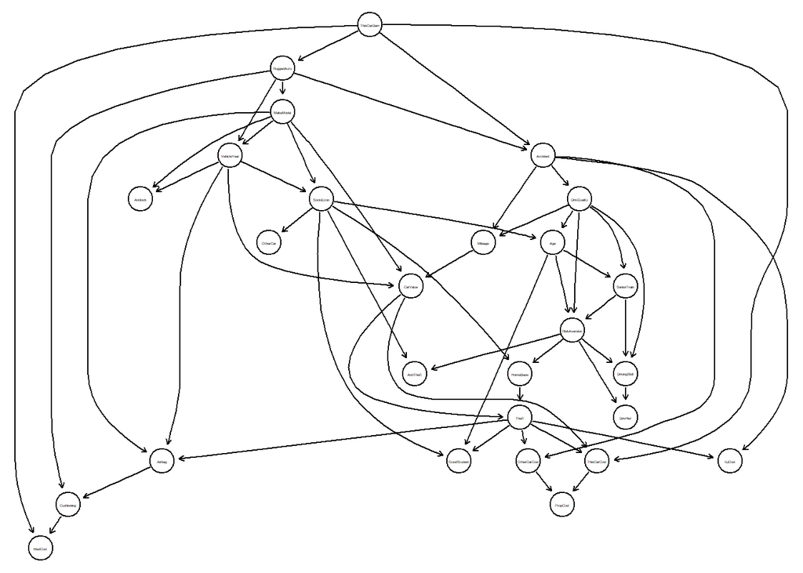

```r
graphviz.plot(mod1)
```

# Esercizio 2.2

Con la rete precedentemente ottenuta: estrarre gli archi orientati (hint:usa arcs()). Quanti archi orientati contiene? Trova i nodi radice della rete, ovvero quelli che sono senza parenti ma con discendenti, trova i nodi isolati, se ce ne sono (quelli senza parenti e senza figli).

```r
library(dplyr)
(arcs <- mod1$arcs)
```

```
##       from           to
##  [1,] "ThisCarDam"   "Accident"
##  [2,] "DrivQuality"  "DrivingSkill"
##  [3,] "RuggedAuto"   "Cushioning"
##  [4,] "VehicleYear"  "Airbag"
##  [5,] "ThisCarDam"   "ThisCarCost"
##  [6,] "MakeModel"    "CarValue"
##  [7,] "SocioEcon"    "HomeBase"
##  [8,] "RuggedAuto"   "MakeModel"
##  [9,] "MakeModel"    "SocioEcon"
## [10,] "DrivingSkill" "DrivHist"
## [11,] "ThisCarCost"  "PropCost"
## [12,] "Accident"     "DrivQuality"
## [13,] "Accident"     "OtherCarCost"
## [14,] "RiskAversion" "AntiTheft"
```

[output cut: 40 more lines]

```r
nrow(directed.arcs(mod1))
```

```
## [1] 54
```

```r
(directed.arcs(mod1))
```

```
##       from           to
##  [1,] "ThisCarDam"   "Accident"
##  [2,] "DrivQuality"  "DrivingSkill"
##  [3,] "RuggedAuto"   "Cushioning"
##  [4,] "VehicleYear"  "Airbag"
##  [5,] "ThisCarDam"   "ThisCarCost"
##  [6,] "MakeModel"    "CarValue"
##  [7,] "SocioEcon"    "HomeBase"
##  [8,] "RuggedAuto"   "MakeModel"
##  [9,] "MakeModel"    "SocioEcon"
## [10,] "DrivingSkill" "DrivHist"
## [11,] "ThisCarCost"  "PropCost"
## [12,] "Accident"     "DrivQuality"
## [13,] "Accident"     "OtherCarCost"
## [14,] "RiskAversion" "AntiTheft"
```

[output cut: 40 more lines]

```r
for (node in nodes(mod1)) {
    print(paste0("Nodo ", node))
    if (length(which(mod1$arcs[, 1] == node)) > 0)
        print(mod1$arcs[which(mod1$arcs[, 1] == node), 2])
    else
        print("senza figli")
    }
```

```
## [1] "Nodo GoodStudent"
## [1] "senza figli"
## [1] "Nodo Age"
## [1] "SeniorTrain"  "RiskAversion" "GoodStudent"
## [1] "Nodo SocioEcon"
## [1] "HomeBase"    "AntiTheft"   "OtherCar"    "Age"         "GoodStudent"
## [1] "Nodo RiskAversion"
## [1] "AntiTheft"    "HomeBase"     "DrivHist"     "DrivingSkill"
## [1] "Nodo VehicleYear"
## [1] "Airbag"    "SocioEcon" "Antilock"  "CarValue"
## [1] "Nodo ThisCarDam"
## [1] "Accident"    "ThisCarCost" "MedCost"     "RuggedAuto"
## [1] "Nodo RuggedAuto"
## [1] "Cushioning"  "MakeModel"   "Accident"    "VehicleYear"
## [1] "Nodo Accident"
```

[output cut: 48 more lines]

```r
for (node2 in root.nodes(mod1)) {
    print(paste0("Nodo radice ", node2))
    if (length(which(mod1$arcs[, 1] == node2)) == 0)
        print(paste0("Nodo isolato ", node2))
    else
        print("Nodo non isolato")
    }
```

```
## [1] "Nodo radice ThisCarDam"
## [1] "Nodo non isolato"
```

Ci sono 27 nodi per 54 archi su un unico nodo radice. Non ci sono nodi isolati.

# Esercizio 3

Effettuare l’apprendimento strutturale di una rete bayesiana impiegando hill climbing con score “bde”: il risultato NON DEVE contenere gli archi orientati sotto riportati(opzione blacklist). Nella tabella qualsiasi altro denota tutti i nodi meno quella già considerato. Rappresentare in una figura il grafo ottenuto in output usando la funzione plot(). Quanti archi orientati contiene?

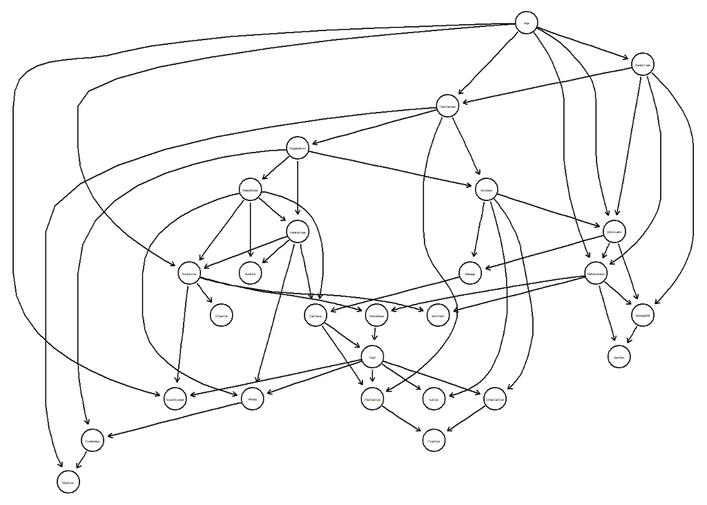

```r
bl1 <- cbind(names(insuranceDF[, -2]), rep("Age", length(names(insuranceDF[, -2]))))
bl2 <- cbind(rep("PropCost", length(names(insuranceDF[, -20]))), names(insuranceDF[, -20]))
bl3 <- cbind(rep("DrivHist", length(names(insuranceDF[, -27]))), names(insuranceDF[, -27]))
bl <- rbind(bl1, bl2, bl3)
mod.2 <- hc(insuranceDF, score = "bde", blacklist = bl)
graphviz.plot(mod.2)
```

```r
nrow(directed.arcs(mod.2))
```

```
## [1] 56
```

```r
directed.arcs(mod.2)
```

```
##       from           to
##  [1,] "ThisCarDam"   "Accident"
##  [2,] "DrivQuality"  "DrivingSkill"
##  [3,] "RuggedAuto"   "Cushioning"
##  [4,] "VehicleYear"  "Airbag"
##  [5,] "ThisCarDam"   "ThisCarCost"
##  [6,] "MakeModel"    "CarValue"
##  [7,] "SocioEcon"    "HomeBase"
##  [8,] "RuggedAuto"   "MakeModel"
##  [9,] "MakeModel"    "SocioEcon"
## [10,] "DrivingSkill" "DrivHist"
## [11,] "ThisCarCost"  "PropCost"
## [12,] "Accident"     "DrivQuality"
## [13,] "Accident"     "OtherCarCost"
## [14,] "RiskAversion" "AntiTheft"
```

[output cut: 42 more lines]

La rete contiene 56 archi orientati.

# Esercizio 4.1

Effettuare l’apprendimento strutturale di una rete bayesiana impiegando hill climbing con score “bic”: assicurarsi che il risultato contenga gli archi orientati sotto riportati (opzione whitelist). Rappresentare in una figura il grafo ottenuto in output usando la funzione plot(). Quanti archi orientati contiene?

```r
wl <- rbind(c("SeniorTrain", "ThisCarDam"), c("MedCost", "RuggedAuto"), c("SocioEcon", "GoodStudent"),
          c("Age", "RiskAversion"), c("Age", "ThisCarDam"), c("RuggedAuto", "VehicleYear"))
mod.3 <- hc(insuranceDF, score = "bic", whitelist = wl)
```

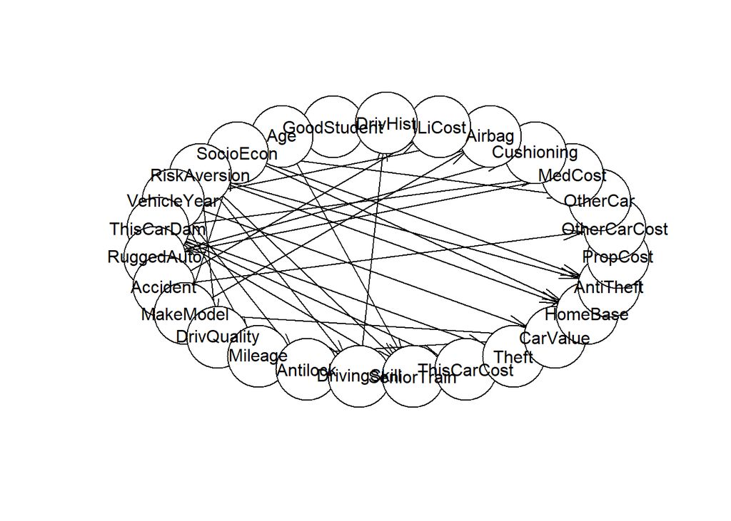

```r
plot(mod.3)
```

```r
nrow(directed.arcs(mod.3))
```

```
## [1] 45
```

```r
directed.arcs(mod.3)
```

```
##       from           to
##  [1,] "Age"          "RiskAversion"
##  [2,] "Age"          "ThisCarDam"
##  [3,] "SocioEcon"    "GoodStudent"
##  [4,] "RuggedAuto"   "VehicleYear"
##  [5,] "SeniorTrain"  "ThisCarDam"
##  [6,] "MedCost"      "RuggedAuto"
##  [7,] "ThisCarDam"   "Accident"
##  [8,] "DrivQuality"  "DrivingSkill"
##  [9,] "RuggedAuto"   "Cushioning"
## [10,] "VehicleYear"  "Airbag"
## [11,] "ThisCarDam"   "ThisCarCost"
## [12,] "MakeModel"    "CarValue"
## [13,] "SocioEcon"    "HomeBase"
## [14,] "RuggedAuto"   "MakeModel"
```

[output cut: 31 more lines]

La rete ha 45 archi orientati.

# Esercizio 4.2

Esegui il codice seguente e cambiare posizione degli archi del DAG con mouse (fatto)

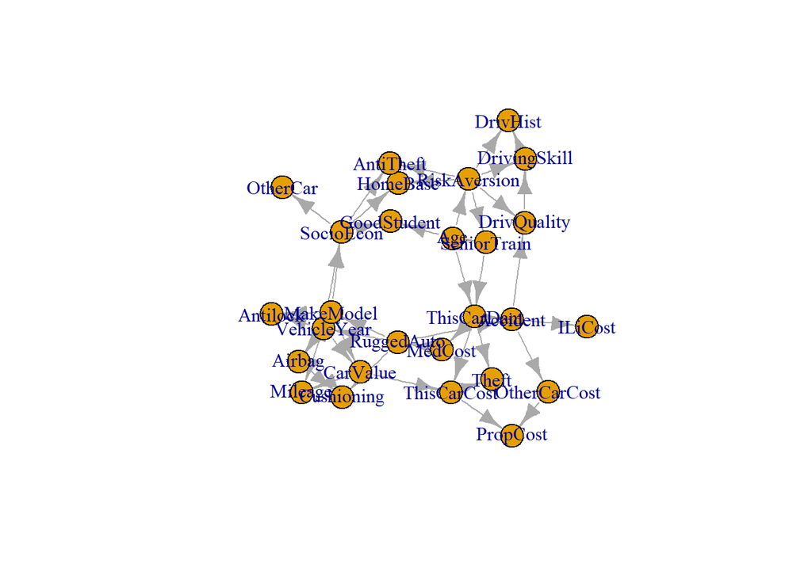

```r
modello3 <- graph_from_data_frame(arcs(mod.3), directed = TRUE, vertices = NULL)
plot(modello3)
```

```r
idbn <- tkplot(modello3)
tk_set_coords(idbn, 2 * tk_coords(idbn))
coordinate <- tk_coords(idbn, norm = FALSE)
tk_close(idbn)
```

# Esercizio 5

Confrontare le due reti ottenute con hill climbing con blacklist verso whitelist usando compare()

```r
bnlearn::compare(mod.2, mod.3, arcs = FALSE)
```

```
## $tp
## [1] 38
##
## $fp
## [1] 7
##
## $fn
## [1] 18
```

```r
bnlearn::compare(mod.2, mod.3, arcs = TRUE)
```

```
## $tp
##       from           to
##  [1,] "ThisCarDam"   "Accident"
##  [2,] "DrivQuality"  "DrivingSkill"
##  [3,] "RuggedAuto"   "Cushioning"
##  [4,] "VehicleYear"  "Airbag"
##  [5,] "ThisCarDam"   "ThisCarCost"
##  [6,] "MakeModel"    "CarValue"
##  [7,] "SocioEcon"    "HomeBase"
##  [8,] "RuggedAuto"   "MakeModel"
##  [9,] "MakeModel"    "SocioEcon"
## [10,] "DrivingSkill" "DrivHist"
## [11,] "ThisCarCost"  "PropCost"
## [12,] "Accident"     "DrivQuality"
## [13,] "Accident"     "OtherCarCost"
```

[output cut: 56 more lines]

Le due reti hanno 38 archi uguali.

# Esercizio 6

Considera il DAG ottenuto al punto (3). Stima i parametri di tale rete bayesiana con bn.fit(). Estrai la distribuzione di probabilità condizionata di “Theft” condizionata a “ThisCarCost = TenThou” e “ThisCarDam = Moderate”.

```r
fit = bn.fit(mod.3, insuranceDF)
mod.3$arcs[which(mod.3$arcs[, 2] == "Theft")]
```

```
## [1] "ThisCarCost" "ThisCarDam"
```

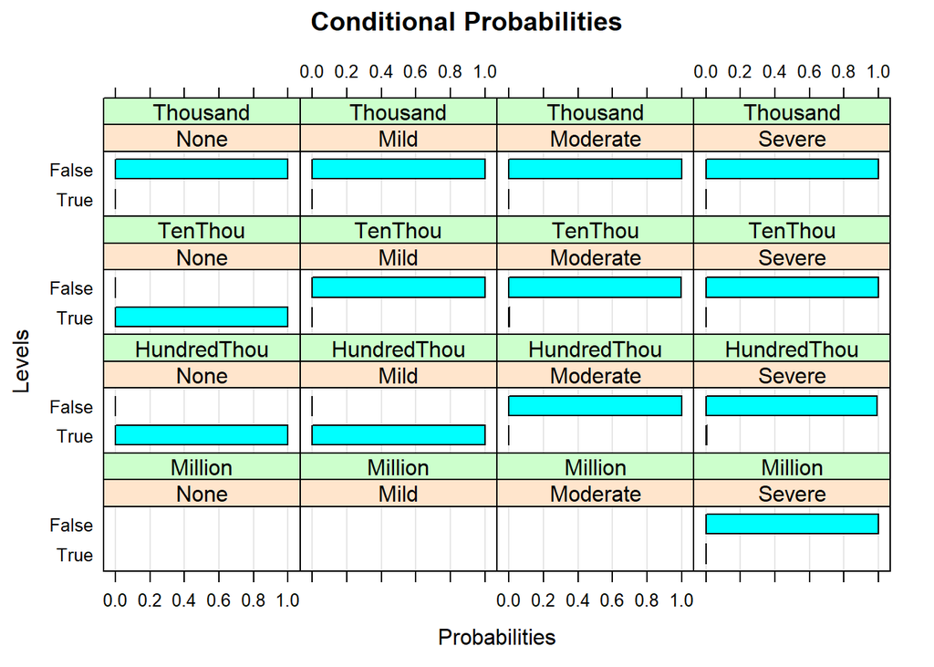

```r
theftProb <- fit$Theft
bn.fit.barchart(theftProb)
```

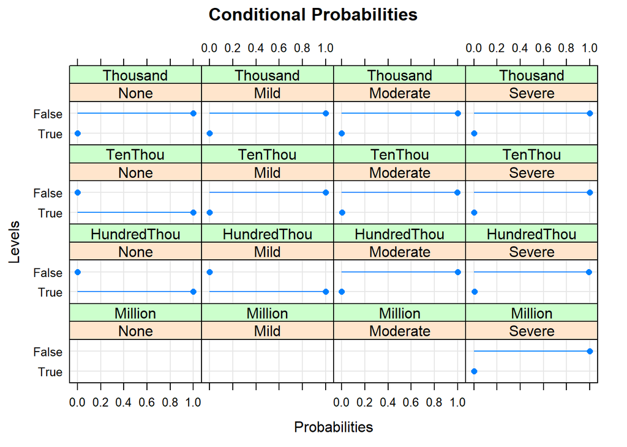

```r
bn.fit.dotplot(theftProb)
```

```r
theftProbab <- as.data.frame(fit$Theft$prob)
str(theftProbab)
```

```
## 'data.frame':    32 obs. of  4 variables:
##  $ Theft      : Factor w/ 2 levels "True","False": 1 2 1 2 1 2 1 2 1 2 ...
##  $ ThisCarDam : Factor w/ 4 levels "None","Mild",..: 1 1 2 2 3 3 4 4 1 1 ...
##  $ ThisCarCost: Factor w/ 4 levels "Thousand","TenThou",..: 1 1 1 1 1 1 1 1 2 2 ...
##  $ Freq       : num  0.000275 0.999725 0 1 0 ...
```

```r
freq <- filter(theftProbab, ThisCarCost == "TenThou", ThisCarDam == "Moderate")
freq
```

```
##   Theft ThisCarDam ThisCarCost        Freq
## 1  True   Moderate     TenThou 0.002770083
## 2 False   Moderate     TenThou 0.997229917
```

La probabilità che la macchina sia rubata per un costo di decine di migliaia di dollari e con danni di moderata entità è molto bassa

# Esercizio 7.1

Impiegando il DAG ottenuto come mod2, stabilire se PropCost è indipendente da RiskAversion condizionatamente a MakeModel,DrivQuality,Theft usando un teorema di separazione per DAG.

```r
require(pcalg)
mod.2.graphnel <- as.graphNEL(mod.2)
pcalg::dsep("PropCost", "RiskAversion", c("MakeModel", "DrivQuality", "Theft"), mod.2.graphnel)
```

```
## [1] FALSE
```

Propcost non è indipendente da RiskAdversion alle condizioni sopra richieste!

# Esercizio 7.2

Con simulate genera via simulazione Monte Carlo un dataset di 10000 realizzazioni della rete ottenuta come mod2. Stampa a schermo le distribuzioni marginali delle frequenze relative di ogni variabile per tale dataset simulato.

```r
mod.2.fit <- bn.fit(mod.2, insuranceDF)
mod2gr <- as.grain(mod.2.fit)
sim <- simulate(mod2gr, nsim = 10000)
str(sim)
```

```
## 'data.frame':    10000 obs. of  27 variables:
##  $ GoodStudent : Factor w/ 2 levels "True","False": 2 2 2 2 2 2 1 2 2 2 ...
##  $ Age         : Factor w/ 3 levels "Adolescent","Adult",..: 2 2 2 1 3 2 1 1 2 2 ...
##  $ SocioEcon   : Factor w/ 4 levels "Prole","Middle",..: 2 2 1 2 1 2 1 1 1 2 ...
##  $ RiskAversion: Factor w/ 4 levels "Psychopath","Adventurous",..: 4 3 4 2 3 3 2 2 3 4 ...
##  $ VehicleYear : Factor w/ 2 levels "Current","Older": 1 2 2 2 2 2 2 2 2 2 ...
##  $ ThisCarDam  : Factor w/ 4 levels "None","Mild",..: 4 4 1 3 1 1 2 1 1 4 ...
##  $ RuggedAuto  : Factor w/ 3 levels "EggShell","Football",..: 1 2 1 1 1 1 1 1 1 1 ...
##  $ Accident    : Factor w/ 4 levels "None","Mild",..: 4 4 1 3 1 1 2 1 1 4 ...
##  $ MakeModel   : Factor w/ 5 levels "SportsCar","Economy",..: 1 3 2 1 2 2 1 2 2 2 ...
##  $ DrivQuality : Factor w/ 3 levels "Poor","Normal",..: 1 1 3 1 2 2 1 1 2 1 ...
##  $ Mileage     : Factor w/ 4 levels "FiveThou","TwentyThou",..: 3 4 2 2 2 2 2 3 4 3 ...
##  $ Antilock    : Factor w/ 2 levels "True","False": 1 2 2 2 2 2 2 2 2 2 ...
##  $ DrivingSkill: Factor w/ 3 levels "SubStandard",..: 1 1 2 1 2 2 1 1 2 1 ...
##  $ SeniorTrain : Factor w/ 2 levels "True","False": 2 2 2 2 1 2 2 2 2 2 ...
##  $ ThisCarCost : Factor w/ 4 levels "Thousand","TenThou",..: 3 2 1 2 1 1 1 1 1 2 ...
##  $ Theft       : Factor w/ 2 levels "True","False": 2 2 2 2 2 2 2 2 2 2 ...
##  $ CarValue    : Factor w/ 5 levels "FiveThou","TenThou",..: 3 1 2 2 1 1 1 1 1 1 ...
##  $ HomeBase    : Factor w/ 4 levels "Secure","City",..: 1 3 2 3 2 3 2 2 4 3 ...
##  $ AntiTheft   : Factor w/ 2 levels "True","False": 1 2 1 2 2 2 2 2 2 1 ...
##  $ PropCost    : Factor w/ 4 levels "Thousand","TenThou",..: 3 3 1 3 1 1 1 1 1 4 ...
##  $ OtherCarCost: Factor w/ 4 levels "Thousand","TenThou",..: 1 2 1 2 1 1 1 1 1 3 ...
##  $ OtherCar    : Factor w/ 2 levels "True","False": 1 1 2 1 1 1 2 2 2 1 ...
##  $ MedCost     : Factor w/ 4 levels "Thousand","TenThou",..: 4 2 1 1 1 1 1 1 1 1 ...
##  $ Cushioning  : Factor w/ 4 levels "Poor","Fair",..: 1 3 1 2 1 1 1 2 1 1 ...
##  $ Airbag      : Factor w/ 2 levels "True","False": 1 1 2 2 2 2 1 2 2 2 ...
##  $ ILiCost     : Factor w/ 4 levels "Thousand","TenThou",..: 4 2 1 1 1 1 1 1 1 3 ...
##  $ DrivHist    : Factor w/ 3 levels "Zero","One","Many": 3 3 1 3 1 1 3 3 1 2 ...
```

```r
modsim <- hc(sim, score = "bde")
```

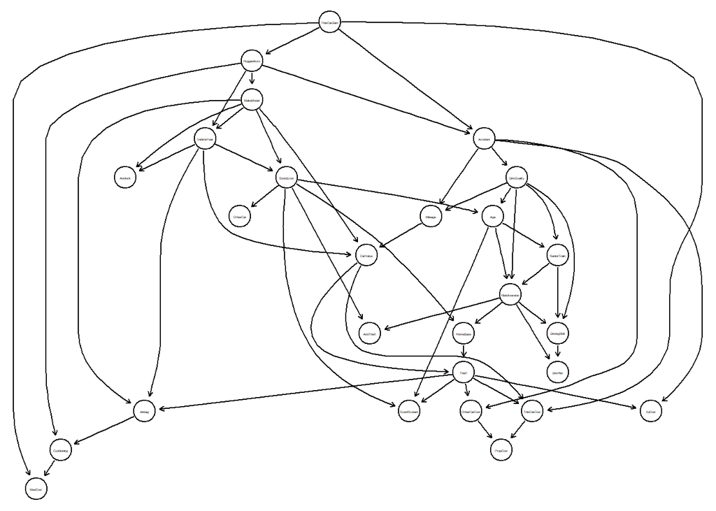

```r
d <- graphviz.plot(modsim);
```

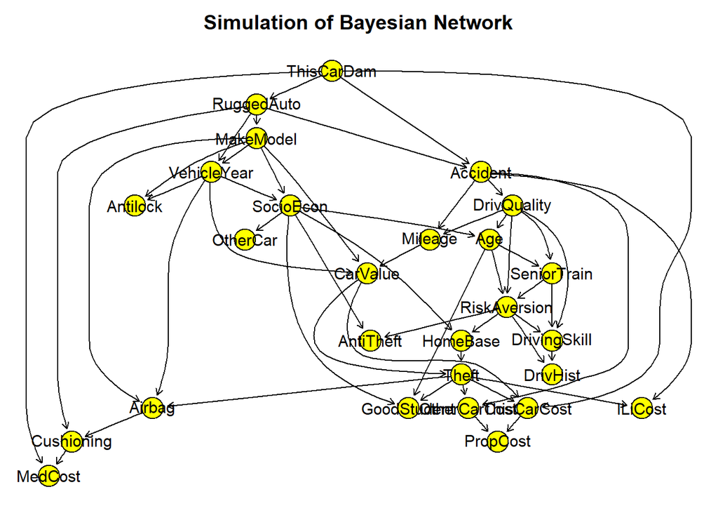

```r
plot(d, main = "Simulation of Bayesian Network", attrs = list(node = list(fillcolor = "yellow", fontsize = 70),
            edge = list(color = "black"),
            graph = list(rankdir = "UD")))
```

```r
for (var in names(sim)) {
    print(sim %>%
          group_by_(var) %>%
          summarise(n = n()) %>%
          mutate(freq = n / sum(n)))
}
```

```
## # A tibble: 2 x 3
##   GoodStudent     n   freq
##        <fctr> <int>  <dbl>
## 1        True   399 0.0399
## 2       False  9601 0.9601
## # A tibble: 3 x 3
##          Age     n   freq
##       <fctr> <int>  <dbl>
## 1 Adolescent  2015 0.2015
## 2      Adult  6075 0.6075
## 3     Senior  1910 0.1910
## # A tibble: 4 x 3
##     SocioEcon     n   freq
##        <fctr> <int>  <dbl>
## 1       Prole  4156 0.4156
## 2      Middle  3629 0.3629
## 3 UpperMiddle  2128 0.2128
## 4     Wealthy    87 0.0087
## # A tibble: 4 x 3
##   RiskAversion     n   freq
##         <fctr> <int>  <dbl>
## 1   Psychopath   138 0.0138
## 2  Adventurous  2514 0.2514
## 3       Normal  4905 0.4905
## 4     Cautious  2443 0.2443
## # A tibble: 2 x 3
##   VehicleYear     n   freq
##        <fctr> <int>  <dbl>
## 1     Current  3524 0.3524
## 2       Older  6476 0.6476
## # A tibble: 4 x 3
##   ThisCarDam     n   freq
##       <fctr> <int>  <dbl>
## 1       None  7285 0.7285
## 2       Mild   768 0.0768
## 3   Moderate   669 0.0669
## 4     Severe  1278 0.1278
## # A tibble: 3 x 3
##   RuggedAuto     n   freq
##       <fctr> <int>  <dbl>
```

[output cut: 114 more lines]

```
## 1   True  4346 0.4346
## 2  False  5654 0.5654
## # A tibble: 4 x 3
##       ILiCost     n   freq
##        <fctr> <int>  <dbl>
## 1    Thousand  9657 0.9657
## 2     TenThou   159 0.0159
## 3 HundredThou   112 0.0112
## 4     Million    72 0.0072
## # A tibble: 3 x 3
##   DrivHist     n   freq
##     <fctr> <int>  <dbl>
## 1     Zero  5764 0.5764
## 2      One  1190 0.1190
## 3     Many  3046 0.3046
```

# Esercizio 8

Dalla rete ottenuta come mod.2, si assuma di aver rilevato le evidenze seguenti: Age sia “Adult”; RiskAversion sia “Psychopath”; AntiTheft sia “True”; MakeModel sia “SportCar”; *PropCost sia “HundredThou”; Crea un oggetto gRain basato su mod.2 e calcola la probabilità condizionata dell’evento CarValue = “FiftyThou” date le evidenze sopra elencate. Confronta tale valore di probabilità con il valore prima di inserire l’evidenza (prima del condizionamento).

```r
mod2grain <- as.grain(mod.2.fit)
MPCarValue <- querygrain(mod2grain, nodes = c("CarValue"))
MPCarValue[[1]]["FiftyThou"]
```

```
##  FiftyThou
## 0.09868044
```

```r
ev <- list(Age = "Adult",
                 RiskAversion = "Psychopath",
                 AntiTheft = "True",
                 MakeModel = "SportsCar",
                 PropCost = "HundredThou")

CarValueCond <- querygrain(mod2grain, nodes = c("CarValue"), evidence = ev)
CarValueCond[[1]]["FiftyThou"]
```

```
## FiftyThou
## 0.0971415
```

```r
MPCarValue[[1]]["FiftyThou"] - CarValueCond[[1]]["FiftyThou"]
```

```
##   FiftyThou
## 0.001538944
```

La probabilità condizionata dell’evento CarValue = “FiftyThou” è 0.09868044. Dopo il condizionamento diventa del 0.0971415, perdendo lo 0.001538944